# RIRO (v.1.0) - Russian Index of the Research Organizations

Lutay A.V. (RFBR, [orcid](https://orcid.org/0000-0003-1341-781X))

Sterligov I.A. (HSE, [orcid](https://orcid.org/0000-0001-9736-4713))

05/25/2021

[IN RUSSIAN](https://openriro.github.io)

## What is RIRO?

RIRO, as the article’s title suggests, is a project launched in May 2021 and devoted to the Russian organizations doing research. What title does not tell is that RIRO was designed as a public, open, and autonomous project, where

- **public** tells that anyone can use it (free as in speech);
- **open** suggests that anyone can contribute to it (no strings attached);
- **autonomous** stresses the fact that the project is self-governed (free as a bird).

In its current form RIRO v.1.0 is a set of tables linking the organization identifiers and profiles from various international registries (see a list below) to the Russian legal entities.

- [Wikidata](https://www.wikidata.org/)
- [ROR](https://ror.org/)
- [GRID](https://www.grid.ac/)
- [Microsoft Academic](https://academic.microsoft.com/home)
- [Scopus](https://www.elsevier.com/solutions/scopus)
- [SciVal](https://www.elsevier.com/solutions/scival)
- [Web of Science](https://clarivate.com/webofsciencegroup)
- [InCites](https://clarivate.com/webofsciencegroup/solutions/incites/)
- [University Monitoring System by the Ministry of Science & Higher Education](https://monitoring.miccedu.ru/?m=vpo).

All files are available at Zenodo: https://zenodo.org/communities/riro/.

The code and examples of use will be shared via GitHub: https://github.com/OpenRIRO.

## Why do we need RIRO?

The project’s main purpose is to create and link the profiles (PID) corresponding to the Russian research organizations in the various information systems. One may argue that in those identifiers are already assigned to some organizaions. It looks so, but each register of identifiers has its own handicaps - some are trying to keep the most updated orgnames and rename the accounts, wiping out old names and connections; the others have more conservative record update policy and provide a lot of obsolete names; most do not follow the Russian mergers in science; and none is great in covering the small organizations (which is a terra incognita for any citation index). As a result, the identifiers provided by the international services suffer from a patchy coverage and have a limited value for the research assessment and scientometric analysis.

An UpSet diagram below shows the sets of organizations listen in RIRO (v.1.0) and matched to the various identifiers. Only the head and active (existing) organizations are counted here, so the identifiers referring to the branches or to the predecessors liquidated via acquisition, are not counted.

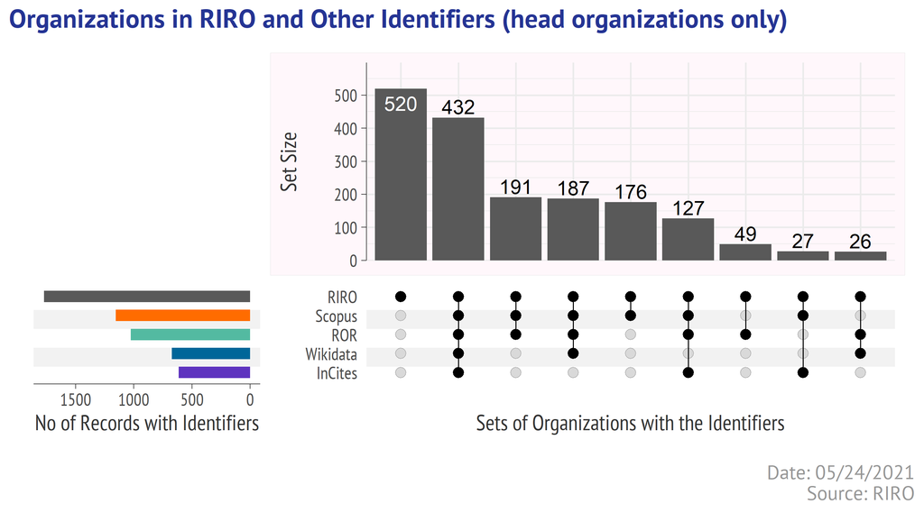

With the RIRO we aim to:

- create, update, and share a public dataset of the organization identifiers that reflects not only their current statuses, but also their recent (at least) transformations;
- asssess how complete is a representation of the Russian organizations in the international registries;
- attract the researh community’s attention to the new information services and its features.

## Selection Criteria for Organizations

RORI is about research, so in general any organization that appear in the affiliations of the scientific articles is a good candidate for RORI. Participation is free (as in speech). And yet some organizations have been prioritized to appear in v.1.0, those are:

- state (federal/regonal) organizations doing fundamental or applied research (research centres, scientific institutes, universities, large clinical centers or hospitals, reserves, museums, etc.);
- private organizations (mostly universities).

We have not even reviewed the entities associated with the Russian state corporations (RosAtom, RosSpace, RosTech) or the military ones.

## Special Notes

- RIRO does not copy **all the attributes** linked to the records in the sources. We selected only the most useful (to our opinion) fields. In future RIRO releases we may add more fields.
- The data in the tables 4-11 is the same as in the original sources - we have not changed the original records.
- Some tables share the common fields. For example, ROR (table 4) has a column Wikidata, and Wikidata (table 5) has a column ROR. We did not chang or check those links, they are kept as they are present in the original sources, but renamed to avoid confusion (added a prefix referring to the source - ror_wikidata, wd_ror, etc.
- Matching the identifiers to the organizations was made based on available information (name, location) - we have not checked if the data asssociated with the identifiers (in the source databases) is correctly assigned to the organizations.

## RIRO dataset

The RIRO dataset (as a set of CSV tables) can be downloaded from Zenodo [community](https://zenodo.org/communities/riro/), via [OAI-PMH Harvesting API](https://zenodo.org/oai2d?verb=ListRecords&set=user-riro&metadataPrefix=oai_dc) or by using [REST API](https://developers.zenodo.org/). Zenodo – is one of the leading data repositories supported by CERN ([details](https://help.zenodo.org/features/)).

The CSV tables share a primary key named code, so one can easily join the tables or build a database.

Below are the parts of each table corrsponding to the 3 organizations selected as an example:

- Komi Federal Research Centre of the Ural branch of the Russian Academy of Sciences
- Tomsk National Medical Research Centre
- Russian Technological University MIREA

## Table 1 - Official Info

This table comprises the basic organization details - OGRN (Primary State Registration Number), INN (Taxpayer Identification Number), KPP (Tax Registration Reason Code), full & short names, status {active, liquidated, in reorganization process}, and the branch type {head or branch}.

A table below lists the legal entities found by OGRN and their branches (the branch organization and its head entity share same OGRN and INN). To save some space a column with the short names column is not included.

| code | level | status | name_full | ogrn | inn | kpp |
| --- | --- | --- | --- | --- | --- | --- |
| n4p9t7 | Head | Действующая организация | ФЕДЕРАЛЬНОЕ ГОСУДАРСТВЕННОЕ БЮДЖЕТНОЕ УЧРЕЖДЕНИЕ НАУКИ ФЕДЕРАЛЬНЫЙ ИССЛЕДОВАТЕЛЬСКИЙ ЦЕНТР КОМИ НАУЧНЫЙ ЦЕНТР УРАЛЬСКОГО ОТДЕЛЕНИЯ РОССИЙСКОЙ АКАДЕМИИ НАУК | 1021100511332 | 1101481574 | 110101001 |
| w6n9h2 | Head | Действующая организация | ФЕДЕРАЛЬНОЕ ГОСУДАРСТВЕННОЕ БЮДЖЕТНОЕ НАУЧНОЕ УЧРЕЖДЕНИЕ ТОМСКИЙ НАЦИОНАЛЬНЫЙ ИССЛЕДОВАТЕЛЬСКИЙ МЕДИЦИНСКИЙ ЦЕНТР РОССИЙСКОЙ АКАДЕМИИ НАУК | 1027000861568 | 7019011979 | 701701001 |
| i7x2s7 | Branch | Действующая организация | ТЮМЕНСКИЙ КАРДИОЛОГИЧЕСКИЙ НАУЧНЫЙ ЦЕНТР - ФИЛИАЛ ФЕДЕРАЛЬНОГО ГОСУДАРСТВЕННОГО БЮДЖЕТНОГО НАУЧНОГО УЧРЕЖДЕНИЯ ТОМСКИЙ НАЦИОНАЛЬНЫЙ ИССЛЕДОВАТЕЛЬСКИЙ МЕДИЦИНСКИЙ ЦЕНТР РОССИЙСКОЙ АКАДЕМИИ НАУК | 1027000861568 | 7019011979 | 720343001 |
| y5b3t9 | Head | Действующая организация | ФЕДЕРАЛЬНОЕ ГОСУДАРСТВЕННОЕ БЮДЖЕТНОЕ ОБРАЗОВАТЕЛЬНОЕ УЧРЕЖДЕНИЕ ВЫСШЕГО ОБРАЗОВАНИЯ МИРЭА - РОССИЙСКИЙ ТЕХНОЛОГИЧЕСКИЙ УНИВЕРСИТЕТ | 1037739552740 | 7729040491 | 772901001 |
| s8t3r2 | Branch | Действующая организация | ФИЛИАЛ ФЕДЕРАЛЬНОГО ГОСУДАРСТВЕННОГО БЮДЖЕТНОГО ОБРАЗОВАТЕЛЬНОГО УЧРЕЖДЕНИЯ ВЫСШЕГО ОБРАЗОВАНИЯ МИРЭА - РОССИЙСКИЙ ТЕХНОЛОГИЧЕСКИЙ УНИВЕРСИТЕТ В Г. СТАВРОПОЛЕ | 1037739552740 | 7729040491 | 263543001 |
| r2i9t5 | Branch | Действующая организация | ФИЛИАЛ ФЕДЕРАЛЬНОГО ГОСУДАРСТВЕННОГО БЮДЖЕТНОГО ОБРАЗОВАТЕЛЬНОГО УЧРЕЖДЕНИЯ ВЫСШЕГО ОБРАЗОВАНИЯ МИРЭА - РОССИЙСКИЙ ТЕХНОЛОГИЧЕСКИЙ УНИВЕРСИТЕТ В Г. ФРЯЗИНО МОСКОВСКОЙ ОБЛАСТИ | 1037739552740 | 7729040491 | 505203001 |

Each row has its unique code whih serves as a primary key for all the tables of the RIRO database.

## Table 2 - Locations and Geodata

Table 2 comprises the full address and its separate parts (in Russian), accompanied with the geocode, geo coordinates and time zone. Table 2 is the only table in RIRO having 1:1 correspondance to Table 1 via code. The other tables can have few rows for one code.

| code | geoname_id | lat | lon | time | federal_district | address_full | postal_code | region_type | region | city | settlement_type | settlement | street_type | street | house_type | house | block_type_full | block |
| --- | --- | --- | --- | --- | --- | --- | --- | --- | --- | --- | --- | --- | --- | --- | --- | --- | --- | --- |
| n4p9t7 | 485239 | 61.6660239 | 50.8235666 | UTC+3 | Северо-Западный | 167982, РЕСПУБЛИКА КОМИ, ГОРОД СЫКТЫВКАР, УЛИЦА КОММУНИСТИЧЕСКАЯ, ДОМ 24 | 167000 | республика | Коми | Сыктывкар |  |  | улица | Коммунистическая | дом | 24 |  |  |
| w6n9h2 | 1489425 | 56.490009 | 84.9458326 | UTC+7 | Сибирский | 634009, ОБЛАСТЬ ТОМСКАЯ, ГОРОД ТОМСК, ПЕРЕУЛОК КООПЕРАТИВНЫЙ, 5 | 634009 | область | Томская | Томск |  |  | переулок | Кооперативный | дом | 5 |  |  |
| i7x2s7 | 1488754 | 57.134939 | 65.5663861 | UTC+5 | Уральский | 625026, ОБЛАСТЬ ТЮМЕНСКАЯ, ГОРОД ТЮМЕНЬ, УЛИЦА МЕЛЬНИКАЙТЕ, ДОМ 111 | 625026 | область | Тюменская | Тюмень |  |  | улица | Мельникайте | дом | 111 |  |  |
| y5b3t9 | 524901 | 55.6733309 | 37.4801249 | UTC+3 | Центральный | 119454, ГОРОД МОСКВА, ПРОСПЕКТ ВЕРНАДСКОГО, 78 | 119454 | город | Москва | Москва |  |  | проспект | Вернадского | дом | 78 |  |  |
| s8t3r2 | 487846 | 45.0521865 | 41.9126233 | UTC+3 | Северо-Кавказский | 355035, КРАЙ СТАВРОПОЛЬСКИЙ, ГОРОД СТАВРОПОЛЬ, ПРОСПЕКТ КУЛАКОВА, ДОМ 8, КВ-Л 601 | 355035 | край | Ставропольский | Ставрополь |  |  | проспект | Кулакова | дом | 8 |  |  |
| r2i9t5 | 562319 | 55.9657426 | 38.0488063 | UTC+3 | Центральный | 141190, ОБЛАСТЬ МОСКОВСКАЯ, ГОРОД ФРЯЗИНО, УЛИЦА ВОКЗАЛЬНАЯ, ДОМ 2А | 141190 | область | Московская | Фрязино |  |  | улица | Вокзальная | дом | 2А |  |  |

## Table 3 - Hierarchy

This is a very important table, as it links the parent organizations not only with its current branches, but also with the predecessors (for convenience, in this document both will be referred as “children accounts”).

Table 3 does not pretend to be complete for few reasons:

1. the list includes only the last predecessors of the current organizations, so there is no historical perspective from 2000s or from USSR.
2. some organizations have many branch offices (e.g. hospitals), but information about their hierarchy has little or no value from research assessment perspective. Therefore, for some organizations RIRO does not show the branches. The orgs including the branches are mainly the federal organizations (subdued to the ministries and the federal agencies).

The “child_code” is a code for the children account, and the values in the “relation” column reflect nature of the subordination (it can be a branch or a predecessor).

| code | child_code | relation |
| --- | --- | --- |
| y5b3t9 | s8t3r2 | Филиал |
| y5b3t9 | r2i9t5 | Филиал |
| y5b3t9 | p5p5p9 | Правопредшественники |
| y5b3t9 | n2b3b6 | Правопредшественники |
| y5b3t9 | w3s9x4 | Правопредшественники |
| y5b3t9 | v8s5p4 | Правопредшественники |
| y5b3t9 | g8i5z7 | Правопредшественники |
| y5b3t9 | x3b5x3 | Правопредшественники |
| y5b3t9 | t5m2v3 | Правопредшественники |
| y5b3t9 | g5w8g3 | Правопредшественники |

[output cut: 29 more lines]

So, using a list of OGRNs for 3 selected organizations, we extracted from Table 1 6 entities with unique codes (head & branch organizations), further used to retrieve a list of all the predecessors. As a result we get a list of 42 entities with unique code values.

Let’s look into this list:

| parent_code | parent_org | branch | predecessors |
| --- | --- | --- | --- |
| n4p9t7 | 1 | 0 | 9 |
| w6n9h2 | 1 | 1 | 6 |
| y5b3t9 | 1 | 2 | 21 |

One may note that a list of both head and branch organizations can be retrieved from Table 1, so why to use the table 3? Fair question, let me show you why the RIRO table 3 should not be ignored.

## Table - ROR

Research Organizations Registry (ROR) is an international project launched in 2019 with an ambitious goal to create a public ORCID-like registry for the research organizations. It inherits a lot from GRID (Global Research Identifier Database) and Wikidata. The ROR organization info can be downloaded as a [JSON dump](https://figshare.com/collections/ROR_Data/4596503) or retrieved via [API](https://github.com/ror-community/ror-api).

Table 4 contains not all the Russian-related records from ROR, but only those matched to the organizations present in RORI.

| code | ror_id | grid | ror_name | ror_name_rus | ror_relationships | ror_city | ror_links | ror_aliases | ror_acronyms | ror_status | ror_wikipedia | ror_isni | ror_orgref | ror_wikidata |
| --- | --- | --- | --- | --- | --- | --- | --- | --- | --- | --- | --- | --- | --- | --- |
| t5p4t4 | 00029be75 | grid.483432.a | Institute of Biology of Komi Scientific Centre | Института биологии Коми НЦ УрО РАН | label:Russian Academy of Sciences\|type:Parent\|id:https://ror.org/05qrfxd25 | Syktyvkar | http://ib.komisc.ru/en/ | nstitute of Biology of Komi Scientific Centre of the Ural Branch of the Russian Academy of Sciences | IB Komi SC UB RAS | active |  |  |  |  |
| t6y7n3 | 04ggfw624 | grid.473258.f | Institute of Chemistry, Komi Science Center | Коми научный центр УрО РАН | label:Department of Chemistry and Material Sciences\|type:Parent\|id:https://ror.org/059tqvg48 | Syktyvkar | http://chemi.komisc.ru/en/ | Komi SC |  | active |  | 0000 0000 9097 8504 |  |  |
| r2r5g5 | 02k9pct19 | grid.494805.4 | Institute of Physiology, Komi Science Center | Институт экологической физиологии Уральского отделения | label:Ural Branch of the Russian Academy of Sciences\|type:Parent\|id:https://ror.org/02s4h3z39 | Syktyvkar | http://physiol.komisc.ru |  |  | active |  | 0000 0004 0399 5250 |  |  |
| h4p9g9 | 01tpj7340 | grid.501775.1 | Institute of Geology, Komi Science Centre | Институт геологии Коми НЦ УрО РАН | label:Ural Branch of the Russian Academy of Sciences\|type:Parent\|id:https://ror.org/02s4h3z39 | Syktyvkar | http://geo.komisc.ru/en/ | Institute of Geology, Komi Science Centre, Russian Mineralogical Society |  | active |  |  |  |  |
| w6n9h2 | 01z0w8p93 | grid.473330.0 | Tomsk National Research Medical Center | Томский национальный исследовательский медицинский центр | label:Russian Academy of Sciences\|type:Parent\|id:https://ror.org/05qrfxd25 | Tomsk | http://www.tnimc.ru/en/ |  | TNRMC | active |  |  |  |  |
| w6n9h2 | 05gf3n961 | grid.452262.5 | Tomsk Cancer Research Institute | Томский научно-исследовательский институт онкологии | label:Department of Medical Sciences\|type:Parent\|id:https://ror.org/019zcmj26 | Tomsk | http://www.oncology.tomsk.ru/english/ | Federal State Scientific Institution "Tomsk Research Institute of Oncology" |  | active |  |  |  |  |
| b6h7x5 | 044171329 | grid.465396.b | Research Institute of Pharmacology and Regenerative Medicine named ED Goldberg | Научно-исследовательский институт фармакологии и регенеративной медицины имени Е.Д. Гольдберга | label:Department of Medical Sciences\|type:Parent\|id:https://ror.org/019zcmj26 | Tomsk | http://www.pharmso.ru/ | Federal State Scientific Institution "Research Institute of Pharmacology name ED Goldberg"\|Research Institute of Pharmacology and Regenerative Medicine name ED Goldberg Russian Academy of Medical Sci… | NIIFiRM\|НИИФиРМ | active |  | 0000 0004 4657 0877 |  |  |
| h2v5i8 | 029k7k053 | grid.465310.5 | Research Institute of Medical Genetics of Russian Academy of Medical Sciences | Научно-исследовательский институт медицинской генетики | label:Department of Medical Sciences\|type:Parent\|id:https://ror.org/019zcmj26 | Tomsk | http://www.medgenetics.ru/english/ | Federal State Scientific Institution "Research Institute of Medical Genetics," the Siberian Branch of the Russian Academy of Medical Sciences |  | active |  | 0000 0004 0620 3511 |  |  |
| y6t2i3 | 01sb2fs58 | grid.418894.8 | Institute of Cardiology | Федеральное государственное бюджетное научное учреждение Научно-исследовательский институт кардиологии | label:Department of Medical Sciences\|type:Parent\|id:https://ror.org/019zcmj26 | Tomsk | http://cardio-tomsk.ru/ | Federal State Scientific Institution Research Institute of Cardiology |  | active |  | 0000 0004 0381 144X |  |  |
| x9n5h2 | 026md7341 | grid.465327.1 | Research Institute of Mental Health | Федеральное государственное бюджетное научное учреждение Научно-исследовательский институт психического здоровья | label:Department of Medical Sciences\|type:Parent\|id:https://ror.org/019zcmj26 | Tomsk | http://www.mental-health.ru/ | Federal State Institution "Research Institute of Mental Health" of the Siberian Branch of the Russian Academy of Medical Sciences |  | active |  |  |  |  |

[output cut: 2 more lines]

The column “Relationships” comprise the composite values of following structure:

`label:xxxx|type:yyyyyy|id:https://ror.org/zzzzz`,

with 3 units (label, type, id) for the relative (according to ROR best judgements) organizations.

In cases like ours such references can be misleading - according to ROR the research institutes of the Komi Federal Research Center have different parents:

- label:Department of Chemistry and Material Sciences|type:Parent|id:059tqvg48
- label:Ural Branch of the Russian Academy of Sciences|type:Parent|id:02s4h3z39
- label:Russian Academy of Sciences|type:Parent|id:05qrfxd25

So for a single organization ROR shows 4 accounts subordinating to three different RAS structures.

The truth is that the found 4 research institutes of the Komi Federal Research Center **ceased to exist as legal entities 3 years ago**, they were merged into a single federal research center in May 2018.

That’s the value of Table 3 in RORI - it helps to gather the related identifiers and qualify them as corresponding to a branch or a predecessor.

## Table 5 - Wikidata

WikiData is a public repository of structured data originating from multiple sources. Some sources are more or less consistent (like CrossRef or ISSN), but there’s also a lot of Wikidata records that are created and modified by people. As a result, even though Wikidata offers a pre-defined templates for the profiles of universities and research organizations, many profiles have unpopulated fields.

The table 5 comprises a list of fields found in the Wikidata profiles for the organizations, but not a full copy. Moreover, Table 5 include only those Russian research organizations that match to the organizations in RIRO.

| code | wikidata | wd_itemlabel | wd_rus_orgname | wd_eng_orgname | wd_web_site | wikipedia_eng | wikipedia_rus | wd_itemaltlabel | wd_altlabel | wd_oldnames | wd_isni | wd_elibrary | wd_grid | wd_ror | wd_google | wd_mag | wd_qs | wd_the | wd_ria | wd_umultirank | wd_arwu | wd_cr_funder | wd_doi_pref | wd_twitter | wd_facebook | wd_twitter_id | wd_youtube |
| --- | --- | --- | --- | --- | --- | --- | --- | --- | --- | --- | --- | --- | --- | --- | --- | --- | --- | --- | --- | --- | --- | --- | --- | --- | --- | --- | --- |
| n4p9t7 | Q4229557 | Institute of Chemistry, Komi Science Center | Коми научный центр УрО РАН | Institute of Chemistry, Komi Science Center | chemi.komisc.ru |  |  | Komi SC... | Коми научный центр РАН... |  | 0000 0000 9097 8504 |  | grid.473258.f | 04ggfw624 |  |  |  |  |  |  |  |  |  |  |  |  |  |
| n4p9t7 | Q61931541 | Institute of Geology Komi SC UB RAS | Институт геологии Коми НЦ УрО РАН | Institute of Geology Komi SC UB RAS | geo.komisc.ru |  |  | IG KSC UB RAS, Institute of Geology KSC ... | Институт геологии Коми научного центра У... |  |  |  | grid.501775.1 | 01tpj7340 |  |  |  |  |  |  |  |  |  |  |  |  |  |
| t5p4t4 | Q33121401 | Institute of Biology of Komi Scientific Centre | Института биологии Коми НЦ УрО РАН | Institute of Biology of Komi Scientific Centre | ib.komisc.ru |  |  | IB Komi SC UB RAS, Institute of Biology ... |  |  |  |  | grid.483432.a | 00029be75 |  |  |  |  |  |  |  |  |  |  |  |  |  |
| b6h7x5 | Q30263248 | Research Institute of Pharmacology and Regenerative Medicine named ED Goldberg | Научно-исследовательский институт фармакологии и регенеративной медицины имени Е.Д. Гольдберга | Research Institute of Pharmacology and Regenerative Medicine named ED Goldberg | pharmso.ru |  |  | Federal State Scientific Institution "Re... |  |  | 0000 0004 4657 0877 |  | grid.465396.b | 44171329 |  |  |  |  |  |  |  |  |  |  |  |  |  |
| h2v5i8 | Q30263200 | Research Institute of Medical Genetics of Russian Academy of Medical Sciences | Научно-исследовательский институт медицинской генетики | Research Institute of Medical Genetics of Russian Academy of Medical Sciences | medgenetics.ru |  |  | Federal State Scientific Institution "Re... |  |  | 0000 0004 0620 3511 |  | grid.465310.5 | 029k7k053 |  |  |  |  |  |  |  |  |  |  |  |  |  |
| y6t2i3 | Q4310643 | Institute of Cardiology | НИИ кардиологии ТНЦ СО РАМН | Institute of Cardiology | cardio-tomsk.ru |  |  | Federal State Scientific Institution Res... | Федеральное государственное бюджетное на... |  | 0000 0004 0381 144X |  | grid.418894.8 | 01sb2fs58 |  |  |  |  |  |  |  |  |  |  |  |  |  |
| y5b3t9 | Q3272997 | Moscow State Institute of Radio-engineering Electronics and Automation | МИРЭА | Moscow State Institute of Radio-engineering Electronics and Automation | mirea.ru | https://en.wikipedia.org/wiki/Moscow_Tec... | https://ru.wikipedia.org/wiki/%D0%9C%D0%... | MIREA - Russian Technological University... | Московский институт радиотехники, электр... |  | 0000 0000 9620 717X |  | grid.466477.0 | 04qrtgy16 | /m/03y0ffn | 48336290 |  |  |  |  |  |  |  | mirea_ru |  | 920936018 | UCZA93tbfBUK-ow2NkEshAqg |
| n2b3b6 | Q4304105 | Moscow State University of Instrument Engineering and Computer Science | Московский государственный университет приборостроения и информатики | Moscow State University of Instrument Engineering and Computer Science | old.mgupi.ru | https://en.wikipedia.org/wiki/Moscow_Sta... | https://ru.wikipedia.org/wiki/%D0%9C%D0%... |  | Московский технологический университет (... |  |  |  |  |  | /m/05f3bs6 | 98594063 |  |  |  |  |  |  |  |  |  |  |  |
| z7p3b7 | Q4304107 | Moscow State University of Fine Chemical Technologies | Московский государственный университет тонких химических технологий имени М. В. Ломоносова | Moscow State University of Fine Chemical Technologies | mitht.ru | https://en.wikipedia.org/wiki/Moscow_Sta... | https://ru.wikipedia.org/wiki/%D0%9C%D0%... | Moscow State University of Fine Chemical... | Московский технологический университет (... |  | 0000 0004 0645 9576 |  | grid.419325.8 | 04aty2659 |  | 208875869 |  |  |  |  |  |  |  |  |  |  |  |

## Table 6 - Scopus

Scopus is a (one of leading) citation index accumulating the metadata from 20k+ journal titles, selected conference sources, and some academic book titles. Table 6 lists the Scopus affiliation profiles matched to the organizations in RIRO, and also a number of publications under Scopus affiliation profile (on a data of request, April 2021).

Over 1000 Russian research organizations (and universities) have an access to Scopus under the state-funded centralized subscription, and can use the matched IDs via the online UI or the [API-service](https://dev.elsevier.com/scopus.html). The latter has few wrappers for [python](https://pybliometrics.readthedocs.io/en/stable/) and [R](https://github.com/muschellij2/rscopus) that make working with API more comfortable.

Please note that matching the affiliation profiles to RIRO organizations is based on the affiliation name and city. It does not guarantee that all the publications in the profile are assigned to it correctly. More details on how to edit the affiliation profiles in Scopus can be found on [Elsevier web site](https://service.elsevier.com/app/answers/detail/a_id/25554/supporthub/scopus/).

| code | scopus_id | scopus_affil_name | scopus_affil_name_variants | scopus_affil_city | scopus_affil_country | scopus_affil_pubs |
| --- | --- | --- | --- | --- | --- | --- |
| n4p9t7 | 60004454 | Komi Science Centre Ural Division, Russian Academy of Sciences | Russian Academy Of Sciences | Syktyvkar | Russian Federation | 2425 |
| t5p4t4 | 60105357 | Institute of Biology of the Komi Science Centre of the Ural Branch of the Russian Academy of Sciences | Russian Academy Of Sciences | Syktyvkar | Russian Federation | 1204 |
| x4x3v2 | 60110362 | Institute of Socio- Economic &amp; Energy Problems of North of the Komi Science Centre of the Ural Branch of the Russian Academy of Sciences | Institute Of Socio-economic And Energy Problems Of The North | Syktyvkar | Russian Federation | 45 |
| t6y7n3 | 60110359 | Institute of Chemistry of the Komi Science Centre of the Ural Branch of the Russian Academy of Sciences | Institute Of Chemistry | Syktyvkar | Russian Federation | 656 |
| r2r5g5 | 60110361 | Institute of Physiology of the Komi Scientific Center of the Ural Branch of the Russian Academy of Sciences | Institute Of Physiology | Syktyvkar | Russian Federation | 434 |
| h4p9g9 | 60105307 | Institute of Geology of the Komi Science Centre of the Ural Branch of the Russian Academy of Sciences | Institute Of Geology | Syktyvkar | Russian Federation | 710 |
| n7n4z6 | 60110360 | Institute of Language, Literature and History of the Komi Science Centre of the Ural Branch of the Russian Academy of Sciences | Institute Of Language, Literature And History | Syktyvkar | Russian Federation | 66 |
| n7n4z6 | 123297935 | Literature and History Komi Science Centre of the Russian Academy of Science | Literature And History Komi Science Centre Of The Russian Academy Of Science |  | Russian Federation | 1 |
| w6n9h2 | 60072487 | Tomsk National Research Medical Center, Russian Academy of Sciences | Russian Academy Of Medical Sciences | Tomsk | Russian Federation | 1453 |
| w6n9h2 | 60108892 | Cancer Research Institute, Tomsk National Research Medical Center, Russian Academy of Sciences | Cancer Research Institute | Tomsk | Russian Federation | 736 |

[output cut: 10 more lines]

## Table 7 - Microsoft Academic

[Microsoft Academic Graph](https://www.microsoft.com/en-us/research/project/microsoft-academic-graph/) (MAG) is a database created based on the information extracted with Bing-parsers from the publisher web sites and PDF files [details](https://docs.microsoft.com/en-us/academic-services/project-academic-knowledge/introduction)). This approach is differen from the one utilized by Web of Science and Scopus that receive a large part of information for indexation directly from the publishers.

MAG is also a source of information for many novel solutions like [Lens](https://www.lens.org/), [Semantic Scholar](https://www.semanticscholar.org/), [Open Academic Graph](https://www.microsoft.com/en-us/research/project/open-academic-graph/), Unsub.

Even though the last news about MAG [shocked us too](https://www.microsoft.com/en-us/research/project/academic/articles/microsoft-academic-to-expand-horizons-with-community-driven-approach/), we decided to include the MAG Organization IDs into RORI. Few international companies committed to launching a new tool that may substitute MAG:

> ANNOUNCING: We’re building a replacement for Microsoft Academic Graph. https://t.co/GXelkpt6Zc

> — Our Research (@our_research) [May 8, 2021](https://twitter.com/our_research/status/1391144816549892097?ref_src=twsrc%5Etfw)

> Thanks to [@MSFTResearch](https://twitter.com/MSFTResearch?ref_src=twsrc%5Etfw) for providing the Microsoft Academic Graph (MAG). We’ve been working with MSR and MAG since 2018, and we’ve been collaborating on this transition for some time. 1/3https://t.co/7aHTLio8uK

> — Semantic Scholar (@SemanticScholar) [May 11, 2021](https://twitter.com/SemanticScholar/status/1392265402302963712?ref_src=twsrc%5Etfw)

Table 7 lists just the MAG organization IDs and names agains the RORI codes.

| code | mag_id | mag_orgname |
| --- | --- | --- |
| y5b3t9 | 48336290 | moscow state institute of radio engineering electronics and automation |
| n2b3b6 | 98594063 | moscow state university of instrument engineering and computer science |
| z7p3b7 | 208875869 | moscow state university of fine chemical technologies |

## Table 8 - InCites

InCites is an analytical solution build over Web of Science Core Collection. It allows to export the records, so the matched names can be used for further analysis.

The table 8 lists the official organization names in InCite and Web of Science Core Collection against the RORI codes.

| code | incites_orgname | wos_orgname | wos_pubs_2019_21 |
| --- | --- | --- | --- |
| n4p9t7 | Komi Science Centre of the Ural Branch of the Russian Academy of Sciences | Komi Science Centre Of The Ural Branch Of The Russian Academy Of Sciences | 599 |
| t5p4t4 | Institute of Biology, Komi Scientific Centre, Ural Branch RAS | Institute Of Biology Komi Scientific Centre Ural Branch Ras | 275 |
| t6y7n3 | Institute of Chemistry, Komi Scientific Centre, Ural Branch RAS | Institute Of Chemistry Komi Scientific Centre Ural Branch Ras | 149 |
| r2r5g5 | Institute of Physiology, Komi Scientific Center of the Russian Academy of Sciences | Institute Of Physiology Komi Scientific Center Of The Russian Academy Of Sciences | 70 |
| h4p9g9 | Institute of Geology, Komi Scientific Centre of the Russian Academy of Sciences | Institute Of Geology Komi Scientific Centre Of The Russian Academy Of Sciences | 122 |
| w6n9h2 | Tomsk National Research Medical Center | Tomsk National Research Medical Center | 628 |
| b6h7x5 | E. D. Goldberg Research Institute of Pharmacology & Regenerative Medicine | E D Goldberg Research Institute Of Pharmacology Regenerative Medicine | 79 |
| y6t2i3 | Cardiology Research Institute - Tomsk | Cardiology Research Institute Tomsk | 204 |
| h2z9t3 | Research Institute of Obstetrics, Gynecology & Perinatology - Tomsk |  |  |
| y5b3t9 | MIREA - Russian Technological University | Mirea Russian Technological University | 978 |

[output cut: 1 more lines]

## Table 9 - SciVal

SciVal is an analytical tool build over Scopus. Some Russian organizations have an access to SciVal API and could use the IDs matched against the RORI codes in the table 9.

| code | scival_id | scival_institution_name |
| --- | --- | --- |
| t6y7n3 | 719642 | Institute of Chemistry |
| w6n9h2 | 719242 | RAS - Tomsk National Research Medical Сепtеr |
| b6h7x5 | 719248 | RAS - Goldberg Research Institute of Pharmacology and Regenerative Medicine |
| y6t2i3 | 719244 | RAS - Cardiology Research lnstitute, Tomsk National Research Medical Center |
| y5b3t9 | 708852 | Moscow Technological University |

## Table 10 - Russian Universities Assessment System (by the Ministry of Science & Higher Education)

The system gathers the university statistical reports from all Russian higher education institutions (except some schools under the Ministries of Defence, etc). The reports contain a lot of useful information - from financial to enrollment data.

Table 10 lists the IDs that corresponds to the university’s web page on the portal, matched to the RORI codes.

| code | monitoring_id |
| --- | --- |
| y5b3t9 | 134 |
| s8t3r2 | 14013186 |
| r2i9t5 | 14013178 |

## Table 11 - Web of Science

Web of Science is by far the world’s oldest and most prominent citation index. At this moment Web of Science does not provide the organization IDs that could be used for search or data retrieval, but the search results have the orgaization names. The table 11 lists almost 4000 such names matched to the organizations in RIRO. This is not a complete list of known affiliation names for the Russian research organizations, but we hope to adjust this table in future releases of RIRO.

| code | wos_name_variant | wos_main | wos_incites_main_name |
| --- | --- | --- | --- |
| n4p9t7 | Komi Science Centre Of The Ural Branch Of The Russian Academy Of Sciences | YES | Komi Science Centre Of The Ural Branch Of The Russian Academy Of Sciences |
| t5p4t4 | Institute Of Biology Komi Scientific Centre Ural Branch Ras | YES | Institute Of Biology Komi Scientific Centre Ural Branch Ras |
| t6y7n3 | Institute Of Chemistry Komi Scientific Centre Ural Branch Ras | YES | Institute Of Chemistry Komi Scientific Centre Ural Branch Ras |
| r2r5g5 | Institute Of Physiology Komi Scientific Center Of The Russian Academy Of Sciences | YES | Institute Of Physiology Komi Scientific Center Of The Russian Academy Of Sciences |
| h4p9g9 | Inst Geol Komi Sci Ctr Ub Ras | NO | Institute Of Geology Komi Scientific Centre Of The Russian Academy Of Sciences |
| h4p9g9 | Institute Of Geology Komi Scientific Centre Of The Russian Academy Of Sciences | YES | Institute Of Geology Komi Scientific Centre Of The Russian Academy Of Sciences |
| n7n4z6 | Inst Language Literature Hist Komi Sc Ub Ras | n\a | n\a |
| n7n4z6 | Institute Of Language Literature History Komi Scientific Centre Of The Ras | n\a | n\a |
| w6n9h2 | Canc Res Inst Tomsk Nmrc | NO | Tomsk National Research Medical Center |
| w6n9h2 | Canc Res Inst Tomsk Nrmc | NO | Tomsk National Research Medical Center |

[output cut: 23 more lines]

## All IDs for 3 organizations

An illustration below shows the identifiers (ROR, GRID, Scopus Affiliation ID, InCites ID, MAG, Wikidata) matched to 3 organizations selected as an example. Some IDs correspond to the head organizations, the others either to the branches or to the predecessors.

The identifiers are placed along X-axis, organized in three sections (by organization). The RORI entities are place along Y-axis, the existing organization are shown as squares (the head organizations are also marked with a special sign), the predecessors as circles.

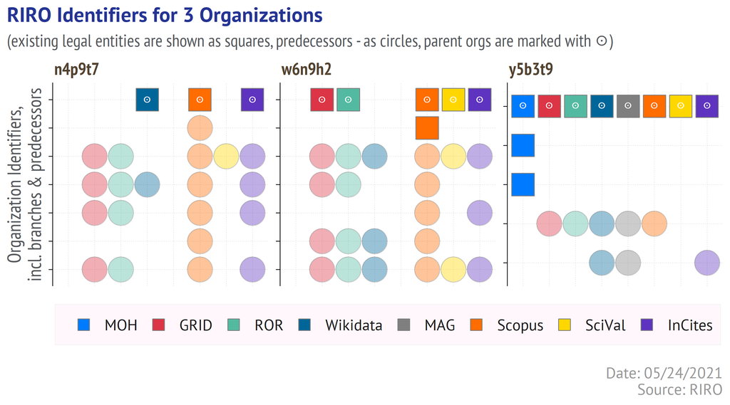

## Feedback

For RIRO v.1.0 we have a [google form (in Russian)](https://docs.google.com/forms/d/e/1FAIpQLScK-USC1BdyaJFudLHHy1Qo2T6ZFnVDLoknRixCfiasJwMbrw/viewform) with the following scenarios of the change requests:

- update the official organization data
- add new organization absent in RIRO
- change a link between the identifier & organization in tables 4-11 (ROR, GRID, Wikidata, etc)
- add new links, missing in the tables 4-11
- suggest a new data source & identifiers).

We do hope that feedback will help us to make RORI a more valuable tool.

Report has been crafted with [R v4.0.0](https://www.r-project.org/), [RStudio v1.2.5042](https://www.rstudio.com/) and R packages:

- [ComplexUpset](https://krassowski.github.io/complex-upset/)
- [DT](https://rstudio.github.io/DT/)
- extrafont
- [scales](https://scales.r-lib.org/)
- [tidyverse](https://www.tidyverse.org/).